# Leukemia microarray data from Yeoh et. al. (2002)

11/05/2021

## Introduction

- The paper from which the dataset is taken is “Classification, subtype discovery, and prediction of outcome in pediatric acute lymphoblastic leukemia by gene expression profiling” written by Yeoh et. al. in 2002 in Cell.
- The study is about pediatric acute lymphoblastic leukemia (ALL), a blood cancer with different subtypes.
- Each subtype has specific characteristics including its response to treatment.
- The goal of the project is to **assess whether there is a link between gene expression and the type of ALL**.

## Introduction

### Leukemia types

- B lineage leukemias containing:
  - t(9;22)[BCR-ABL] – *“BCR”*
  - t(1;19)[E2A-PBX1] – *“E2A”*
  - t(12;21)[TEL-AML1] – *“TEL”*
  - Rearrangements in MLL gene on chromosome 11, band q23 – *“MLL”*
  - Hyperdiploid karyotime – *“Hyperdip”*
- T lineage leukemia:
  - T-ALL – *“T”*

## Materials

- Raw files:
  - raw_stjude_x.tsv.gz, a matrix of 12,625 rows (gene probes) and 327 columns (indivuals);
  - raw_stjude_xrows.tsv.gz with the names of the probes;
  - raw_bcr.xls, an Excel spreadsheet from which we are interested in the first 2 columns giving the equivalence between the probe name and the gene name.
- R with Tidyverse !

## Methods

### Outline of the project

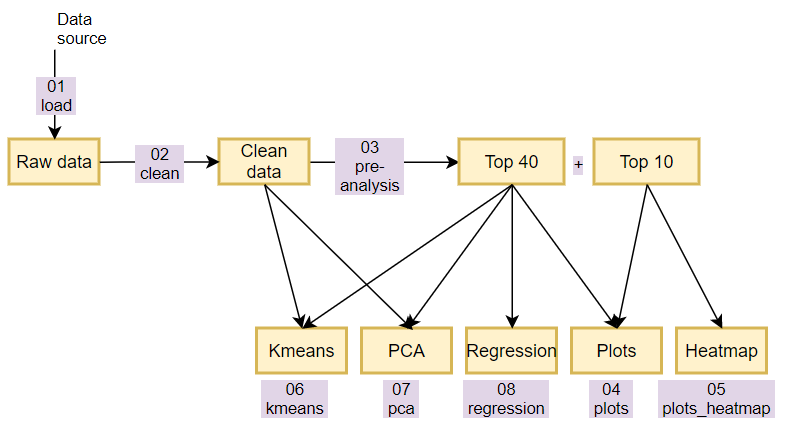

## Methods

### From raw data …

- raw_stjude_x.tsv

```r
# A tibble: 12,625 x 327
   `BCR-ABL-#1` `BCR-ABL-#2` `BCR-ABL-#3` `BCR-ABL-#4` `BCR-ABL-#5` `BCR-ABL-#6` `BCR-ABL-#7` `BCR-ABL-#8`
          <dbl>        <dbl>        <dbl>        <dbl>        <dbl>        <dbl>        <dbl>        <dbl>
 1        1.45         1.34         1.49         1.47         1.49         1.45         1.46         1.51
 2        0.984        1.09         1.10         0.975        0.933        0.968        0.887        0.983
 3        0.892        0.897        0.807        0.969        0.797        0.979        0.919        0.902
 4        1.23         1.28         1.16         1.29         1.18         1.20         1.21         1.24
 5        1.20         1.12         1.12         1.17         1.11         1.10         1.11         1.06
```

## Methods

### From raw data …

- raw_stjude_xrows.tsv

```r
# A tibble: 12,625 x 1
   value
   <chr>
 1 1000_at
 2 1001_at
 3 1002_f_at
 4 1003_s_at
 5 1004_at
```

## Methods

### From raw data …

- raw_bcr.xls

```r
# A tibble: 12,626 x 32
   `Probe set` Descriptions `BCR-ABL-C1...3` `BCR-ABL-C1...4` `BCR-ABL-R1...5` `BCR-ABL-R1...6` `BCR-ABL-R2...7`
   <chr>       <chr>        <chr>            <chr>            <chr>            <chr>            <chr>
 1 NA          NA           Avg Diff         Abs Call         Avg Diff         Abs Call         Avg Diff
 2 AFFX-MurIL~ M16762 Mous~ -2597.800000000~ A                175.69999999999~ A                1249.2
 3 AFFX-MurIL~ M37897 Mous~ -404.1000000000~ A                -512.5           A                -57.60000000000~
 4 AFFX-MurIL~ M25892 Mus ~ 2143.3000000000~ A                737.70000000000~ A                -941.1000000000~
 5 AFFX-MurFA~ M83649 Mus ~ -1697.7          A                1082.3           P                -276.5
```

## Methods

### … to tidy data

- 02_stjude_clean.tsv.gz

```r
# A tibble: 248 x 12,627
   sampleID leukemia Y08200_2 X60188 X60957 X65962 X68149_1 X68149_2 X68277 X07820 U48705 U50648 U51004 Y09305
   <chr>    <chr>       <dbl>  <dbl>  <dbl>  <dbl>    <dbl>    <dbl>  <dbl>  <dbl>  <dbl>  <dbl>  <dbl>  <dbl>
 1 s_1      BCR          1.51   1.45  0.984  0.892     1.23     1.20   1.67  0.870   1.25   2.48   2.39  1.20
 2 s_2      BCR          1.54   1.34  1.09   0.897     1.28     1.12   1.87  0.910   1.67   2.35   2.09  1.16
 3 s_3      BCR          1.60   1.49  1.10   0.807     1.16     1.12   2.63  0.866   1.51   2.20   2.47  1.23
 4 s_4      BCR          1.64   1.47  0.975  0.969     1.29     1.17   2.50  0.910   1.69   2.72   2.26  0.959
 5 s_5      BCR          1.70   1.49  0.933  0.797     1.18     1.11   1.65  0.869   1.63   2.78   1.88  1.08
```

## Methods

- A regular expression to extract the gene name from the Excel column

```r
gene_pattern <- "\\w{1,2}\\d{5,6}"
```

## Methods

- The stringr package to tidy the individuals’ names

```r
x_clean <- x_clean %>%
  separate(col = "id",
           into = c("leukemia"),
           sep = "-")
```

From

```r
"BCR-ABL-#7"
```

we extract

```r
"BCR"
```

which is a type of ALL.

## Methods

- An apply_t_test function to perform selection of the best genes.

```r
apply_t_test = function(data){
  cancer_types <- c("BCR", "E2A", "Hyperdip", "MLL", "T", "TEL")
  my_list <- map(cancer_types,
                 ~ t.test(data %>%
                            filter(leukemia == .x) %>%
                            pull(expr_level),
                          data %>%
                            filter(leukemia != .x) %>%
                            pull(expr_level)) %>%
                   tidy() %>%
                   pull(statistic))
  names(my_list) <- cancer_types
  return(my_list)
}
```

- It is used to select the top 40 and top 10 most differentially expressed genes for each leukemia subtype.

## Results

### Kmeans (all genes)

```
## # A tibble: 16 x 3
##    cluster leukemia counts
##      <dbl> <chr>     <dbl>
##  1       1 T            19
##  2       2 BCR           2
##  3       2 E2A           5
##  4       2 Hyperdip     23
##  5       2 MLL           6
##  6       2 TEL          47
##  7       3 BCR           3
##  8       3 Hyperdip      1
##  9       3 MLL          12
## 10       3 T             1
## 11       4 E2A          22
## 12       4 MLL           2
## 13       5 T            23
## 14       6 BCR          10
## 15       6 Hyperdip     40
## 16       6 TEL          32
```

## Results

### Kmeans (all genes)

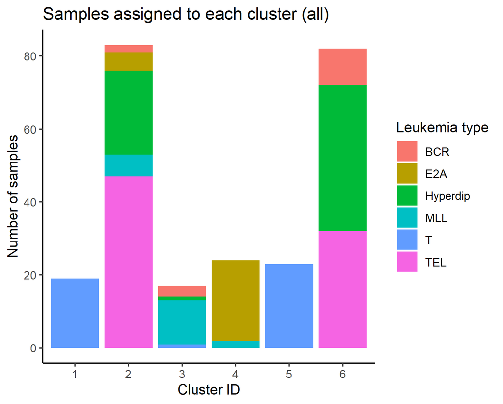

## Results

### Kmeans (top 40 genes)

```
## # A tibble: 12 x 3
##    cluster leukemia counts
##      <dbl> <chr>     <dbl>
##  1       1 Hyperdip      1
##  2       1 T            32
##  3       2 TEL          78
##  4       3 BCR           1
##  5       3 Hyperdip      4
##  6       3 MLL          17
##  7       3 TEL           1
##  8       4 E2A          27
##  9       4 MLL           3
## 10       5 T            11
## 11       6 BCR          14
## 12       6 Hyperdip     59
```

## Results

### Kmeans (top 40 genes)

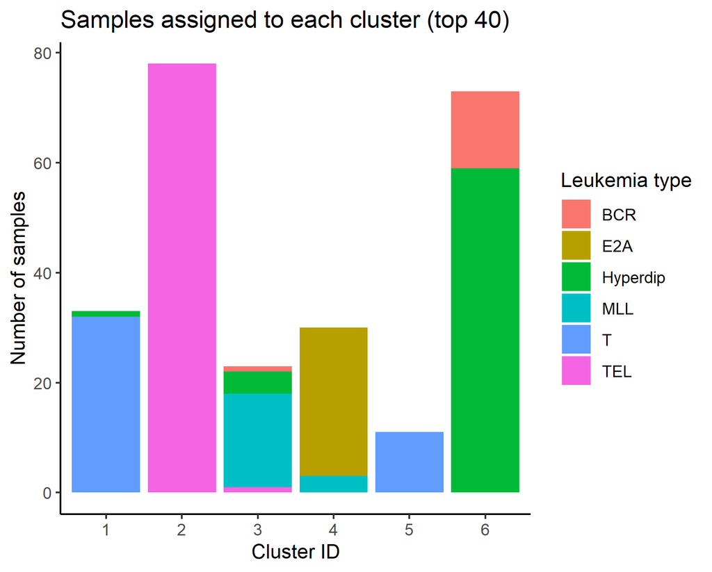

## Results

### PCA

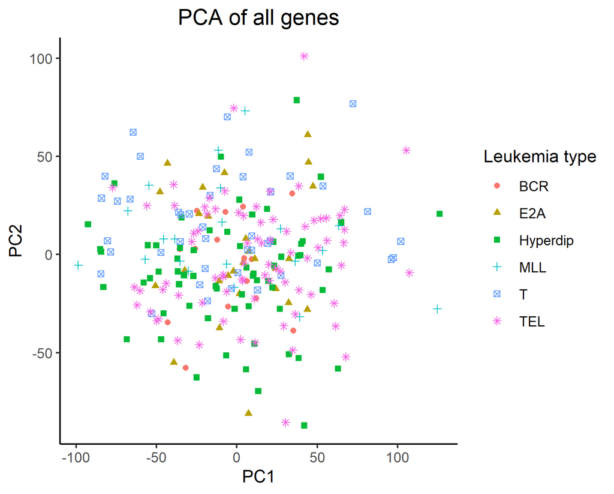

## Results

### PCA

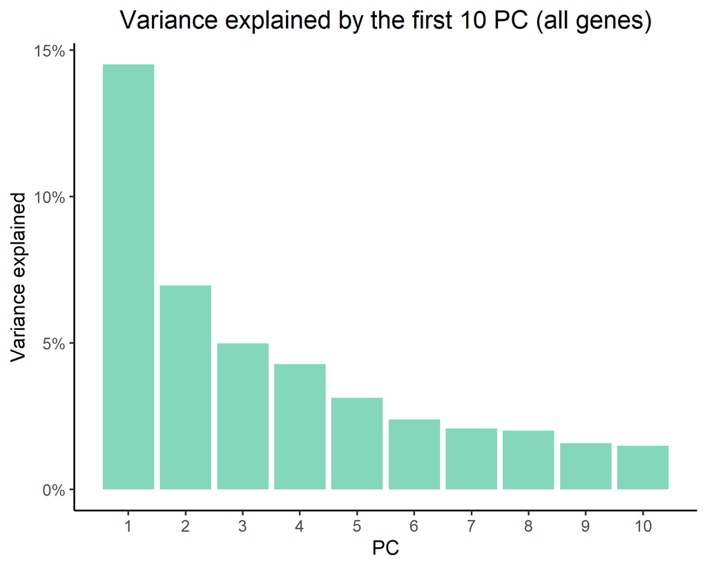

## Results

### PCA

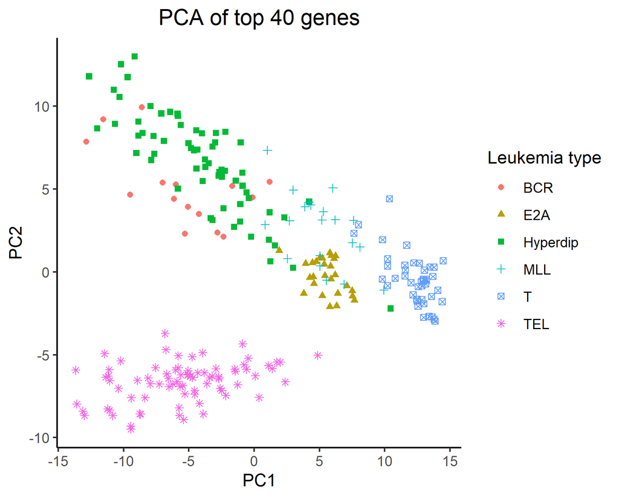

## Results

### PCA

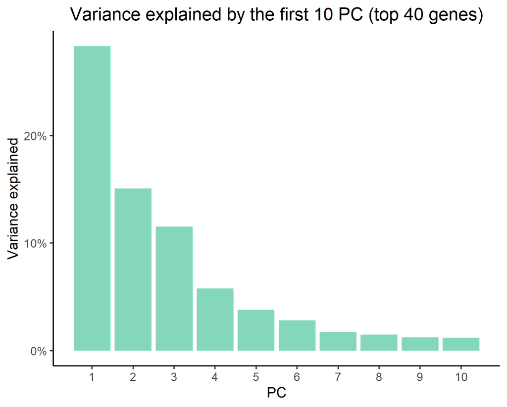

## Results

### Reproducing *Figure 3* from the paper

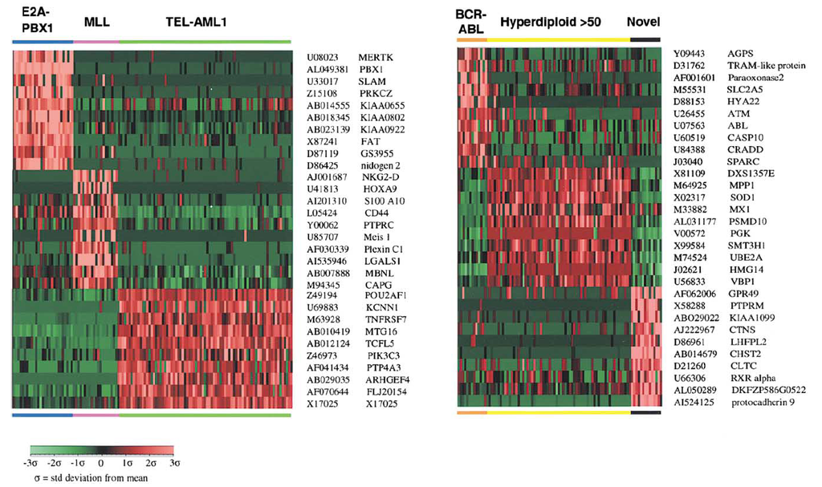

## Results

### Reproducing *Figure 3* from the paper: **Top positively correlated genes**

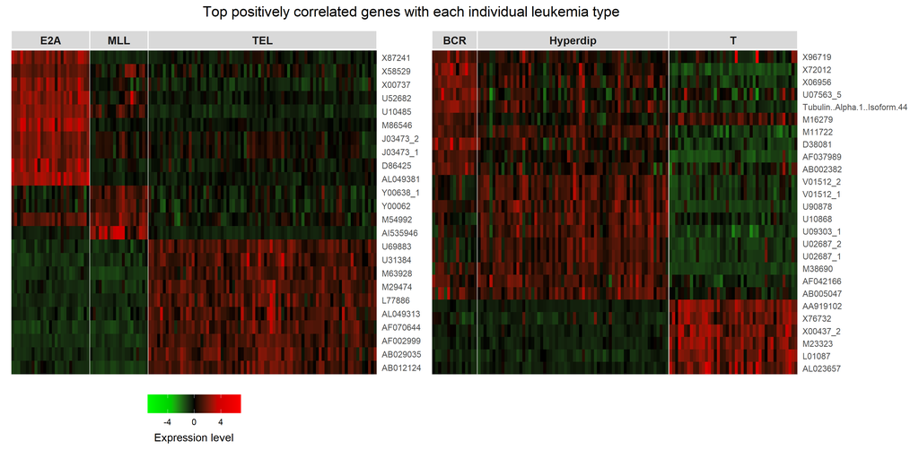

## Results

### Reproducing *Figure 3* from the paper: **Top 10 correlated genes**

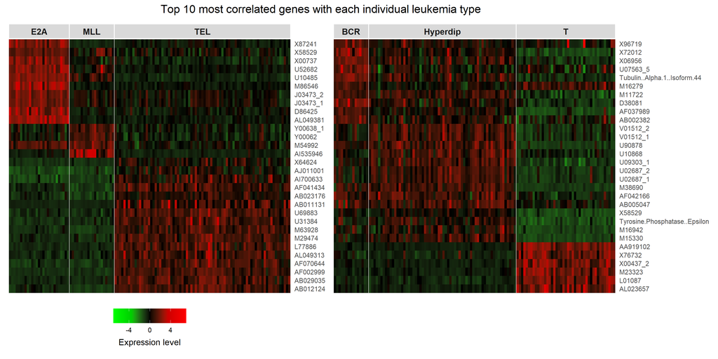

## Results

### Our suggestion: **Top positively correlated genes**

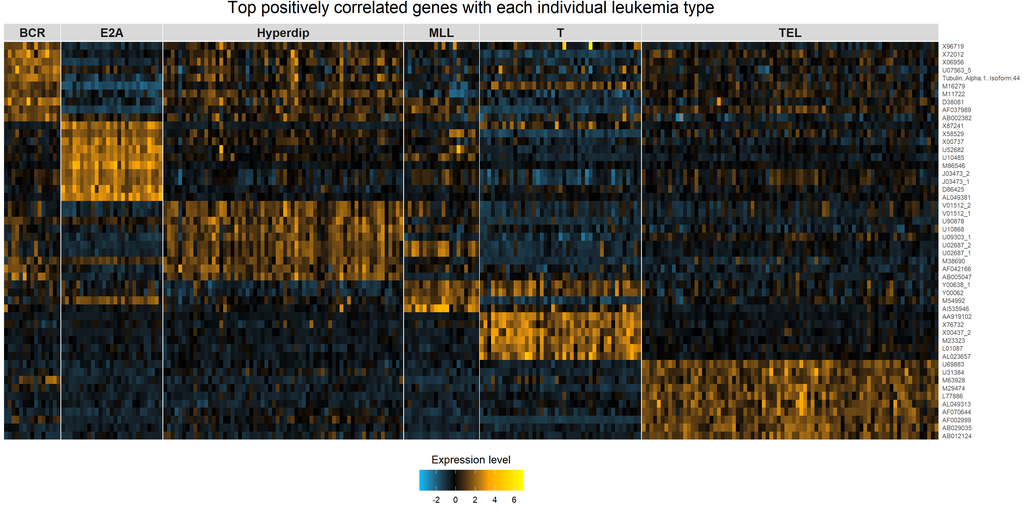

## Results

### Our suggestion: **Top 10 correlated genes**

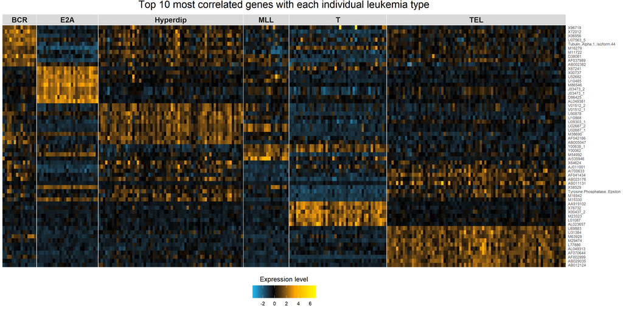

[interactive chart not shown]

[Alternatively, the link](https://paul-simon.shinyapps.io/yeoh_plots/)